# SOM Kohonen

## Identificación de diferentes tipologías de ratones

Para la identificación de las diferentes tipologías de ratones en función de los niveles de expresión de las proteínas, vamos a buscar una red SOM con una topología que reduzca lo máximo posible la precisión de la proyección, teniendo en cuenta otros factores adicionales como el número de puntos respresentados por cada codebook y la densidad de los vecinos. Específicamente, se busca una topología lo más uniforme posible, en la que cada codewook represente aproximadamente la misma cantidad de vectores y con una densidad de vecinos alta, que de pie a una buena clusterización.

```r
set.seed(123)
df.training <- as.matrix(scale(df[,  !names(df) %in% c('MouseID', 'Genotype', 'Treatment', 'Behavior', 'class')]))
df.labels <- as.factor(df[, c('class')])
```

Para la búsqueda de la topología óptima, hemos contruído una malla con los siguientes parámetros:

- x.gSize: cooordenada x del grid de la red SOM
- y.gSize coordenada y del grid de la red SOM
- rSize: radio usado para las vecindades
- topology: topología de la red, pudiendo tomar como valores rectangular o hexagonal

Los resultados se han almacenado en un dataframe, cuyas columnas las conforman los parámetros de la malla y la precisión de la proyección como métrica, la cual (añadiendo unos pesos, dados por la función de probabilidad conjunta de las variables de entrada) es la que el algoritmo SOM minimiza, como explica Kohonen en su artículo self-organizing map.

```r
#set.seed(123)
#som.training.results <- data.frame(distance=double(), x.grid.size=double(), y.grid.size=double(), radius.size=double(), topology=character(), stringsAsFactors=TRUE)
#colnames(som.training.results) <- c('distance', 'x.grid.size', 'y.grid.size', 'radius.size', 'topology')

# Configuración de la malla
#x.gSize <- seq(10, 15, by = 1)
#y.gSize <- seq(10, 15, by = 1)
#rSize <- seq(0.5, 1.5, by = 0.1)
#topology  <- c('rectangular', 'hexagonal')

# Búsqueda del mejor resultado
#for(xgs in y.gSize) {
#  for (ygs in x.gSize) {
      # No se computan soluciones simétricas
#      if(ygs >= xgs) {
#        for(rs in rSize) {
#          for(topo in topology) {
#            som.grid <- somgrid(xdim = xgs, ydim = ygs, topo = topo)
#            som.model <- som(df.training, som.grid, rlen = 700, radius = rs, keep.data = TRUE, dist.fcts = "euclidean")
#            actual.distance <- mean(som.model$distances)
#            print(paste('Distancia media de', actual.distance, 'con tamaño de grid:', xgs, ',', ygs, 'y tamaño de radio', rs, 'y topología:', topo))
#            som.training.results = rbind(som.training.results, c(actual.distance, xgs, ygs, rs, topo))
#        }
#      }
#    }
#  }
#}
```

```r
#  Guardamos el dataframe en un csv

#colnames(som.training.results) <- c('distance', 'x.grid.size', 'y.grid.size', 'radius.size', 'topology')
#path = '/content/gdrive/MyDrive/ModelosSOM/som_best_results.csv'
#write.csv(som.training.results,path, row.names = FALSE)
#saveRDS(som.training.results, file=path)
```

A modo de ejemplo, se muestran algunos registros del dataframe.

```r
# Carga del dataframe

som.training.results <- read.csv(file = 'som_best_results.csv', sep = ",")
head(som.training.results, 10)
```

```
##    distance x.grid.size y.grid.size radius.size    topology
## 1  3.521620          10          10         0.5 rectangular
## 2  3.518390          10          10         0.5   hexagonal
## 3  3.503544          10          10         0.6 rectangular
## 4  3.534114          10          10         0.6   hexagonal
## 5  3.474725          10          10         0.7 rectangular
## 6  3.495802          10          10         0.7   hexagonal
## 7  3.503570          10          10         0.8 rectangular
## 8  3.485085          10          10         0.8   hexagonal
## 9  3.541213          10          10         0.9 rectangular
## 10 3.477752          10          10         0.9   hexagonal
```

Se han probado, mediante ensayo y error, diferentes topologías candidatas teniendo en cuenta los tres parámetros citados más arriba seleccionando el modelo con los siguientes parámetros en particular.

```r
set.seed(123)
som.grid <- somgrid(xdim = 10, ydim = 12, topo = "rectangular")
som.model <- som(df.training, som.grid, rlen = 50, radius = 1.5, keep.data = TRUE, dist.fcts = "euclidean")
summary(som.model)
```

```
## SOM of size 10x12 with a rectangular topology and a bubble neighbourhood function.
## The number of data layers is 1.
## Distance measure(s) used: euclidean.
## Training data included: 1080 objects.
## Mean distance to the closest unit in the map: 3.377.
```

Hemos entrenado el modelo con el menor número de iteraciones hasta encontrar el mínimo de la función de error en la proyección.

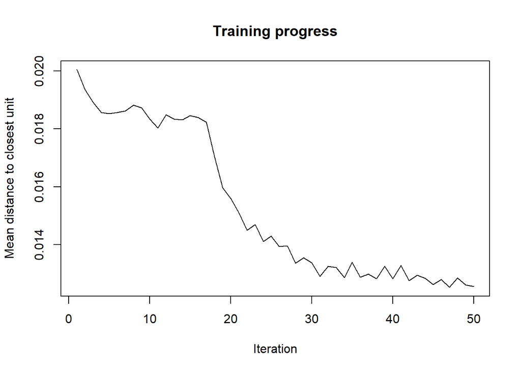

```r
plot(som.model, type="changes")
```

Aunque quedan algunos nodos representando pocos o muchos datos, el mapa se acerca bastante al objetivo de tener un mapa lo más uniforme posible.

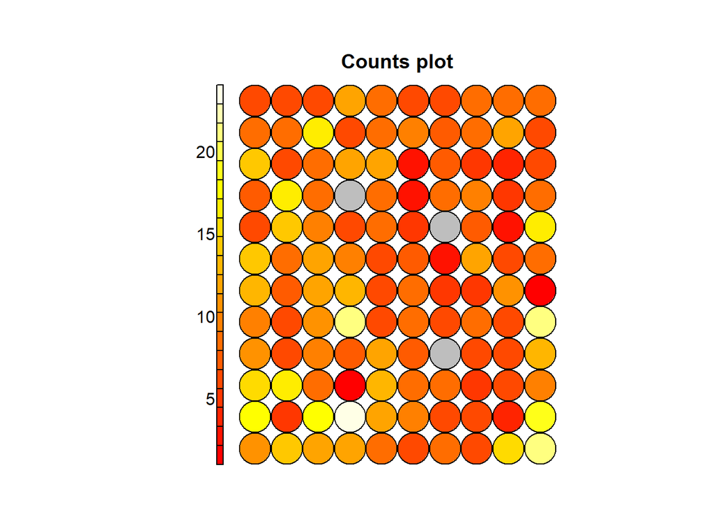

```r
plot(som.model, type = "counts")
```

```r
nb <- table(som.model$unit.classif)
nb
```

```
##
##   1   2   3   4   5   6   7   8   9  10  11  12  13  14  15  16  17  18  19  20
##  11  14  12  12   9   6   8   6  15  21  18   5  18  24  12  10   6   6   4  19
##  21  22  23  24  25  26  27  28  29  30  31  32  33  34  35  36  38  39  40  41
##  15  17   8   1  13   9   9   5   6  10  11   6  10   7  12   7   6   6  13  10
##  42  43  44  45  46  47  48  49  50  51  52  53  54  55  56  57  58  59  60  61
##   6  11  21   6   9   6   9   6  21  13   7  12  13   6   9   5   5  11   1  14
##  62  63  64  65  66  67  68  69  70  71  72  73  74  75  76  78  79  80  81  82
##   9  12  10   6   7   3  12   6   9   6  14  10   6   8   5   7   3  16   7  16
##  83  85  86  87  88  89  90  91  92  93  94  95  96  97  98  99 100 101 102 103
##   8   9   3   9  10   5   9  14   6   8  12  12   3   7   5   4   6   9   9  17
## 104 105 106 107 108 109 110 111 112 113 114 115 116 117 118 119 120
##   6   9  10   7   9  12   6   6   6   6  12   8   6   6   8   9   9
```

El mapa de vecindad indica una distribución de vecinos rica y aproximadamente uniforme.

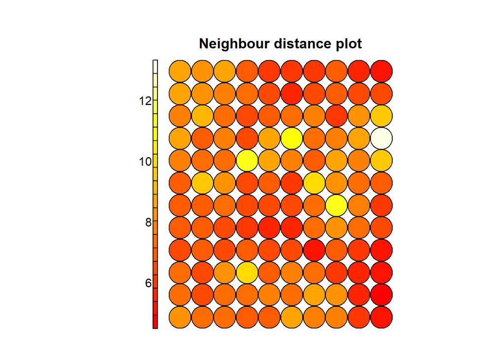

```r
plot(som.model,type="dist.neighbours")
```

Una vez tenemos una topología candidata, usando el criterio del codo para el algoritmo k-means, determinamos cuál es el número óptimo de clústers a representar, usando los codebooks entrenados por el algoritmo som.

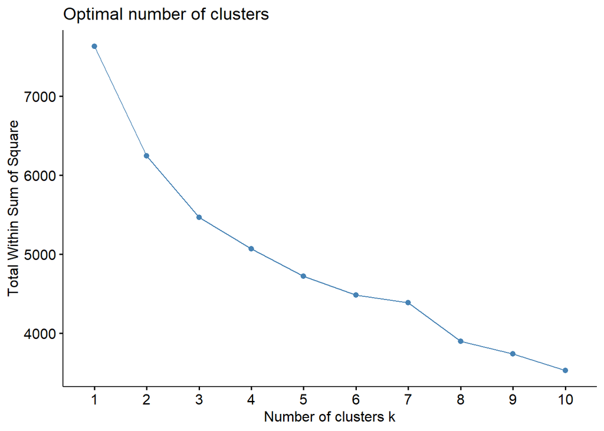

```r
# Método wss: se minimiza la varianza intra grupos
fviz_nbclust(som.model$codes[[1]], kmeans, method = "wss")
```

Seleccionamos $k=8$ como número de clústers.

```
## Too few points to calculate an ellipse
```

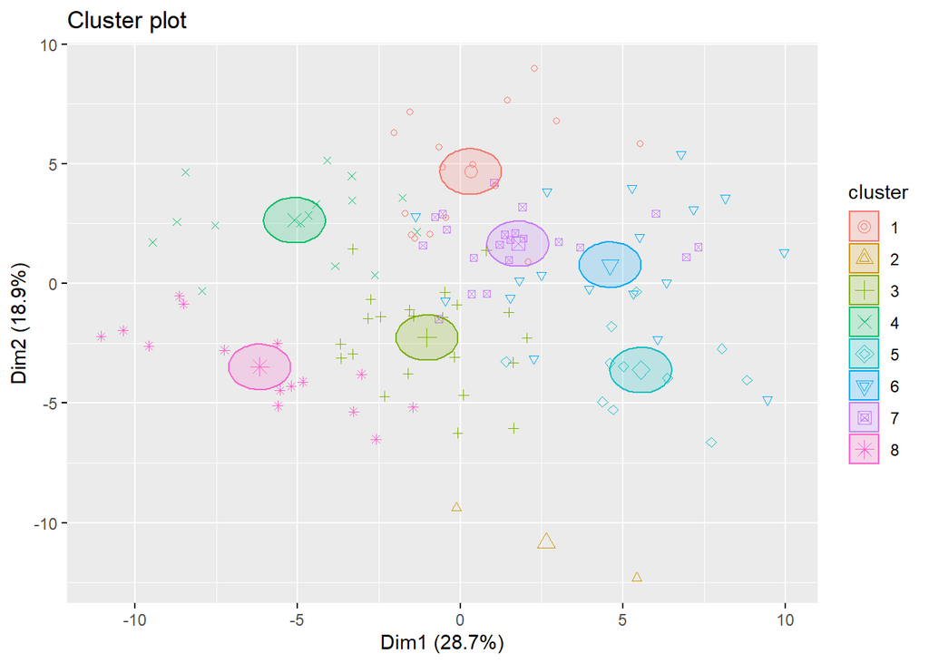

```r
# Representación de los clusters
set.seed(123)
som.cluster <- kmeans(som.model$codes[[1]], 8)
fviz_cluster(som.cluster, data = som.model$codes[[1]], geom = c("point"),ellipse.type = "euclid")
```

La representación segmentada muestra cómo los nodos de los clústers se agrupan formandos pequeños grupos topológicos, lo cual es lo que perseguimos con las redes SOM, aunque no llega a ser del todo precisa, pues vemos cierta mezcla entre las clases.

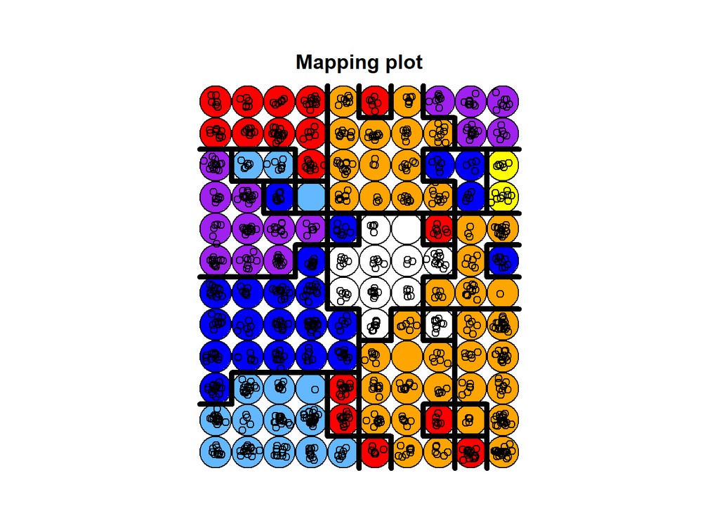

```r
plot(som.model,type="mapping",bgcol=c("red","yellow", 'blue', 'steelblue1', 'white', 'orange', 'orange', 'purple')[som.cluster$cluster])
add.cluster.boundaries(som.model,clustering=som.cluster$cluster)
```

Para ayudar a interpretar los clústers obtenidos en función de las proteínas, usaremos una representación por colores que asocie las proteínas con los clústers.

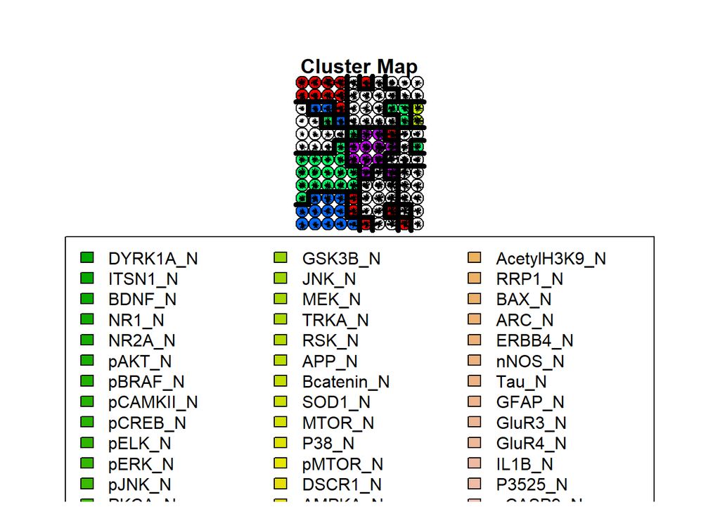

```r
plot(som.model,type="codes",codeRendering = "segments", bgcol = rainbow(5)[som.cluster$cluster], main = "Cluster Map")
add.cluster.boundaries(som.model, som.cluster$cluster)
```

La interpretación de las relaciones clúster-proteínas sólo puede ser dada por alguien experto en la materia.

# Análisis de clasificación mediante xyf

Pasamos a la versión supervisada del algoritmo SOM. Preparamos los datos de entrenamiento, tomando un 20% para los datos de test.

```r
# Inicialización de la semilla
set.seed(123)

# Elminamos las variables relacionadas que contienen, indirectamente, a la variable a predecir y dividimos la muestra en entrenamiento y test
df.ssom <- df[,  !names(df) %in% c('MouseID', 'Genotype', 'Treatment', 'Behavior')]
index <- sample(nrow(df.ssom), nrow(df.ssom)*0.8)


# Normalización de los datos para los datos de entrenamiento
df.train <- scale(df.ssom[index, !names(df.ssom) %in% c('class')])
# Normalización de los datos para los datos de test, usando la media y varianza de los datos de entrenamiento
df.test <- scale(df.ssom[-index, !names(df.ssom) %in% c('class')],
                 center = attr(df.train, "scaled:center"),
                 scale = attr(df.train, "scaled:scale"))



# Extraemos la variable respuesta para los datos de entrenamiento y test
train.label <- as.factor(df.ssom[index, names(df.ssom) %in% c('class')])
test.label <-  as.factor(df.ssom[-index, names(df.ssom) %in% c('class')])
```

Usamos como topología candidata la usada en el apartado anterior.

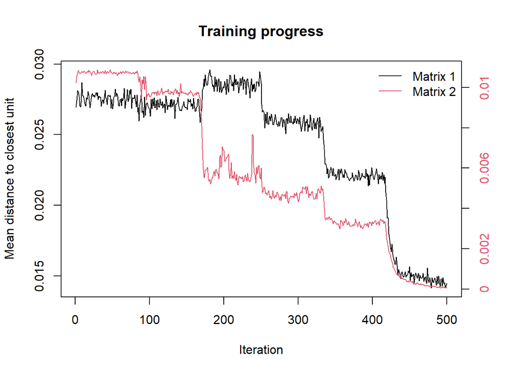

```r
## Entrenamiento de la versión supervisada de SOM
set.seed(100)
sup.som.model <- xyf(df.train, train.label, som.grid, rlen = 500)
plot(sup.som.model, type = "changes")
```

Realizamos las prediciones y construímos la matriz de confusión del modelo.

```r
test.response <- list(independent = df.test, dependent = test.label)
# Predicciones usando la primera capa de SOM
pred <- predict(sup.som.model, newdata = df.test, whatmap = 1)
table(Predict = pred$predictions[[2]], Actual = test.label)
```

```
##         Actual
## Predict  c-CS-m c-CS-s c-SC-m c-SC-s t-CS-m t-CS-s t-SC-m t-SC-s
##   c-CS-m     34      0      0      0      0      0      0      0
##   c-CS-s      1     22      0      0      0      2      0      0
##   c-SC-m      0      0     25      0      0      0      0      0
##   c-SC-s      0      0      1     30      0      0      0      0
##   t-CS-m      0      0      0      0     39      0      0      0
##   t-CS-s      0      0      0      0      0     20      0      0
##   t-SC-m      0      0      2      1      0      0     19      0
##   t-SC-s      0      0      0      0      1      0      0     17
```

```r
confusionMatrix(as.factor(pred$predictions[[2]]), test.label)
```

```
## Confusion Matrix and Statistics
##
##           Reference
## Prediction c-CS-m c-CS-s c-SC-m c-SC-s t-CS-m t-CS-s t-SC-m t-SC-s
##     c-CS-m     34      0      0      0      0      0      0      0
##     c-CS-s      1     22      0      0      0      2      0      0
##     c-SC-m      0      0     25      0      0      0      0      0
##     c-SC-s      0      0      1     30      0      0      0      0
##     t-CS-m      0      0      0      0     39      0      0      0
##     t-CS-s      0      0      0      0      0     20      0      0
##     t-SC-m      0      0      2      1      0      0     19      0
##     t-SC-s      0      0      0      0      1      0      0     17
##
## Overall Statistics
##
##                Accuracy : 0.9626
##                  95% CI : (0.9277, 0.9837)
##     No Information Rate : 0.1869
##     P-Value [Acc > NIR] : < 2.2e-16
##
##                   Kappa : 0.9568
##
##  Mcnemar's Test P-Value : NA
##
## Statistics by Class:
##
##                      Class: c-CS-m Class: c-CS-s Class: c-SC-m Class: c-SC-s
## Sensitivity                 0.9714        1.0000        0.8929        0.9677
## Specificity                 1.0000        0.9844        1.0000        0.9945
## Pos Pred Value              1.0000        0.8800        1.0000        0.9677
## Neg Pred Value              0.9944        1.0000        0.9841        0.9945
## Prevalence                  0.1636        0.1028        0.1308        0.1449
## Detection Rate              0.1589        0.1028        0.1168        0.1402
## Detection Prevalence        0.1589        0.1168        0.1168        0.1449
## Balanced Accuracy           0.9857        0.9922        0.9464        0.9811
##                      Class: t-CS-m Class: t-CS-s Class: t-SC-m Class: t-SC-s
## Sensitivity                 0.9750       0.90909       1.00000       1.00000
## Specificity                 1.0000       1.00000       0.98462       0.99492
## Pos Pred Value              1.0000       1.00000       0.86364       0.94444
## Neg Pred Value              0.9943       0.98969       1.00000       1.00000
## Prevalence                  0.1869       0.10280       0.08879       0.07944
## Detection Rate              0.1822       0.09346       0.08879       0.07944
## Detection Prevalence        0.1822       0.09346       0.10280       0.08411
## Balanced Accuracy           0.9875       0.95455       0.99231       0.99746
```

Representamos la topología comparándola desde el punto de vista de la clusterización obtenida en los apartados anteriores y la variable respuesta, lo cual puede ayudar en la interpretación de los resultados.

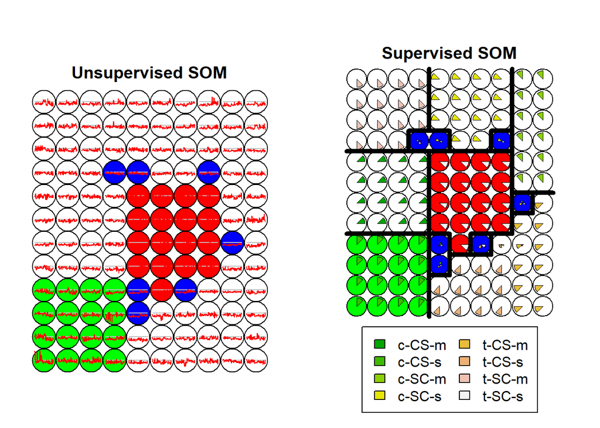

```r
# Representación de
c.class <- kmeans(sup.som.model$codes[[2]], 8)
par(mfrow = c(1,2))
plot(sup.som.model, type = "codes", main = c("Unsupervised SOM", "Supervised SOM"),
     bgcol = rainbow(3)[c.class$cluster])
add.cluster.boundaries(sup.som.model, c.class$cluster)
```

Tanto el algoritmo supervisado como el no supervisado, se basan en una representación topológica de la distribución de las variables de entrada. El hecho de que las predicciones sean tan precisas es un indicativo de que la topología ha sido capaz de representar correctamente las características subyacentes. Además, se observa una relación clara entre los clústers de proteínas y la tipología de ratones. En un plano interpretativo, los resultados dan a entender que cada una de las tipologías diseñadas en el experimento tiene una caracterización distinguida y clara en términos de las proteínas, aunque la interpretación precisa queda en manos de los expertos en la materia.